# Delphi

Ruohao Wu

2023-03-10

This script is used to analyze the the Epi4 performance data. The purpose of this analysis is to compare three different systems

There are the library will be used to do the analyze

```r
# library for plot
library(ggplot2)
# library for data cleaning
library(tidyr)
# Draw RidgeLine Plot
library(ggridges)
# For the pie chart
library(scales)
# To mutate columns
library(dplyr)
```

Read dataset first, we have two different types of dataset with four files. There is one file about tab-delimited queries with two columns and a space-delimited results file with five columns.

The path here can be changed.

```r
# Read the datafile
history <- read.delim("/Users/ruohaowu/Desktop/北美 工作/statsdev-epi4-materials/queries-history.tsv",
                      sep="\t", header = FALSE)
V3 <- read.table("/Users/ruohaowu/Desktop/北美 工作/statsdev-epi4-materials/results-v3-history.txt",
                 header = TRUE)
V4.C <- read.table("/Users/ruohaowu/Desktop/北美 工作/statsdev-epi4-materials/results-v4.C-history.txt",
                 header = TRUE)
V4.M <- read.table("/Users/ruohaowu/Desktop/北美 工作/statsdev-epi4-materials/results-v4.M-history.txt",
                 header = TRUE)
```

After reaeding the file, I notice that history file doesn’t have an index for each query which is different from the other file, for easier analyze for furture work, create a new column named ‘no’ and change the varaible name

```r
# assign a new column called no means the index of each query
history$no <- 1:nrow(history)
# Change the colum name into type and actual
names(history)[1] <- "type"
names(history)[2] <- "actual"
```

```r
# View the observation of each dataset, it doesn't match
nrow(history)
```

```
## [1] 19365
```

```r
nrow(V3)
```

```
## [1] 19359
```

```r
nrow(V4.C)
```

```
## [1] 19359
```

```r
nrow(V4.M)
```

```
## [1] 19359
```

By looking at the observation, we fund the observation of two file doesn’t match, I will check here

```r
# Check whether there is duplicate value
# I would suppose here the no is the primary key and this step is not necessary.
print(any(duplicated(V3$no)))
```

```
## [1] FALSE
```

```r
print(any(duplicated(V4.C$no)))
```

```
## [1] FALSE
```

```r
print(any(duplicated(V4.M$no)))
```

```
## [1] FALSE
```

The result indicates there is no duplicate in each datasets

Could it be there is gap?

```r
# Create dataframe for these index where the difference is not 1
ind_V3 <- data.frame(which(diff(V3$no)!=1))
names(ind_V3)[1] <- "ind"
ind_V3
```

| ind |
| --- |
| 3984 |
| 3985 |
| 3987 |
| 4392 |

```r
ind_V4.C <- data.frame(which(diff(V4.C$no)!=1))
names(ind_V4.C)[1] <- "ind"
ind_V4.C
```

| ind |
| --- |
| 3984 |
| 3985 |
| 3987 |
| 4392 |

```r
ind_V4.M <- data.frame(which(diff(V4.M$no)!=1))
names(ind_V4.M)[1] <- "ind"
ind_V4.M
```

| ind |
| --- |
| 3984 |
| 3985 |
| 3987 |
| 4392 |

```r
# Check whether the index matches for three systems
identical(ind_V3, ind_V4.C)
```

```
## [1] TRUE
```

```r
# This function is designed to see the missing observations

# implement a auto function to remove the unmatched row

if(!all(diff(V3$no) == 1)) {
  # Find indices where difference is not 1
  indices <- which(diff(V3$no) != 1)
  # Find consecutive indices where difference is not 1
  if(identical(ind_V3, ind_V4.C) == TRUE){
    print(ind_V3)
  }
  # Iterate through indices and print corresponding rows
    for (i in ind_V3$ind) {
      row <- V3[i, ]
      next_row <- V3[i+1, ]
      # Find numbers in between two rows
      nums <- (row$no+1):(next_row$no-1)
      print(nums)
      history <- history[-c(nums), ]
    }

}
```

```
##    ind
## 1 3984
## 2 3985
## 3 3987
## 4 4392
## [1] 3985
## [1] 3987 3988 3989
## [1] 3992
## [1] 4398
```

Since the number of index in V3, V4.C, V4.M should be continuous. Then, we can apply the difference function to investigte. There is gap in these files, which means there is missing value. By further looking, the missing values are index 3985, 3987-3989, 3992 and 4398. We should remove them in the history file.

Change the data type of run time in three dataset

```r
for (i in 2:5) {
  V3[,i] <- as.numeric(as.character(V3[,i]))
}

for (i in 2:5) {
  V4.C[,i] <- as.numeric(as.character(V4.C[,i]))
}

for (i in 2:5) {
  V4.M[,i] <- as.numeric(as.character(V4.M[,i]))
}
```

Now,all these file has exactly the same observations with matched resutls and queries.

Should further clean the data in history, since we know the format of query_type is by ’_’

```r
# Split the string into multiple strings based on '__', and put each type as its own column

# Here, I still have something to implement but I don't know how.
# Since the type could be longer than what we have in this dataset,
# only create four more columns is not reasonable
# Need to identify how many axis_name then to create extra column
history_sep <- separate(history, type,
                    into = c("type1", "type2", "type3", "type4"), sep = "__")

# Could use regexp() to find pattern
# regexp()
```

Let’s stop here for initial data cleaning

There are several important varaibles that should be introduced here.

real time: wall-clock time, it includes all the time spent by the program waiting for resources, such as I/O operations or user input, as well as the time spent executing instructions.

User time: It measures the amount of time the CPU spends running the program’s code, excluding time spent waiting for I/O operations or other resources. CPU spent time is an important measure of the efficiency of a program’s algorithm

Sys time: It includes time spent handling system calls, interrupts, and other low-level operations that require privileged access to the system. Kernel spent time is an important measure of the performance of the operating system, as well as the efficiency of the program’s interaction with the system.

# Here, we can perform some summary statistics

```r
summary(V3)
```

```
##        no             real               user               sys
##  Min.   :    1   Min.   : 0.00500   Min.   :0.000000   Min.   :0.000000
##  1st Qu.: 4846   1st Qu.: 0.00600   1st Qu.:0.000000   1st Qu.:0.000000
##  Median : 9686   Median : 0.00700   Median :0.005000   Median :0.000000
##  Mean   : 9685   Mean   : 0.02791   Mean   :0.003656   Mean   :0.001745
##  3rd Qu.:14526   3rd Qu.: 0.01200   3rd Qu.:0.005000   3rd Qu.:0.005000
##  Max.   :19365   Max.   :17.12100   Max.   :0.024000   Max.   :0.010000
##       rows
##  Min.   :    0.0
##  1st Qu.:    0.0
##  Median :    0.0
##  Mean   :  230.6
##  3rd Qu.:  135.0
##  Max.   :19494.0
```

```r
summary(V4.C)
```

```
##        no             real               user               sys
##  Min.   :    1   Min.   : 0.00500   Min.   :0.000000   Min.   :0.000000
##  1st Qu.: 4846   1st Qu.: 0.00700   1st Qu.:0.001000   1st Qu.:0.000000
##  Median : 9686   Median : 0.00800   Median :0.005000   Median :0.000000
##  Mean   : 9685   Mean   : 0.06096   Mean   :0.004051   Mean   :0.002024
##  3rd Qu.:14526   3rd Qu.: 0.02300   3rd Qu.:0.006000   3rd Qu.:0.005000
##  Max.   :19365   Max.   :15.99700   Max.   :0.025000   Max.   :0.011000
##       rows
##  Min.   :    0.0
##  1st Qu.:    0.0
##  Median :    0.0
##  Mean   :  230.6
##  3rd Qu.:  135.0
##  Max.   :19494.0
```

```r
summary(V4.M)
```

```
##        no             real               user               sys
##  Min.   :    1   Min.   : 0.00500   Min.   :0.000000   Min.   :0.000000
##  1st Qu.: 4846   1st Qu.: 0.00700   1st Qu.:0.000000   1st Qu.:0.000000
##  Median : 9686   Median : 0.01000   Median :0.005000   Median :0.000000
##  Mean   : 9685   Mean   : 0.06163   Mean   :0.003843   Mean   :0.001818
##  3rd Qu.:14526   3rd Qu.: 0.03300   3rd Qu.:0.006000   3rd Qu.:0.005000
##  Max.   :19365   Max.   :12.78800   Max.   :0.026000   Max.   :0.011000
##       rows
##  Min.   :    0.0
##  1st Qu.:    0.0
##  Median :    0.0
##  Mean   :  230.6
##  3rd Qu.:  135.0
##  Max.   :19494.0
```

As we can see from each summary statistics, there are several information we should notice

## Real Run Time Analyze

let’s focous on real run time.

let’s take a look at the distribution

```r
# The idea here is to find some tunning parameter that can seet the upper bound of the xlim
# I haven't find one yet
#real_V3 <- quantile(V3$real)[4]
```

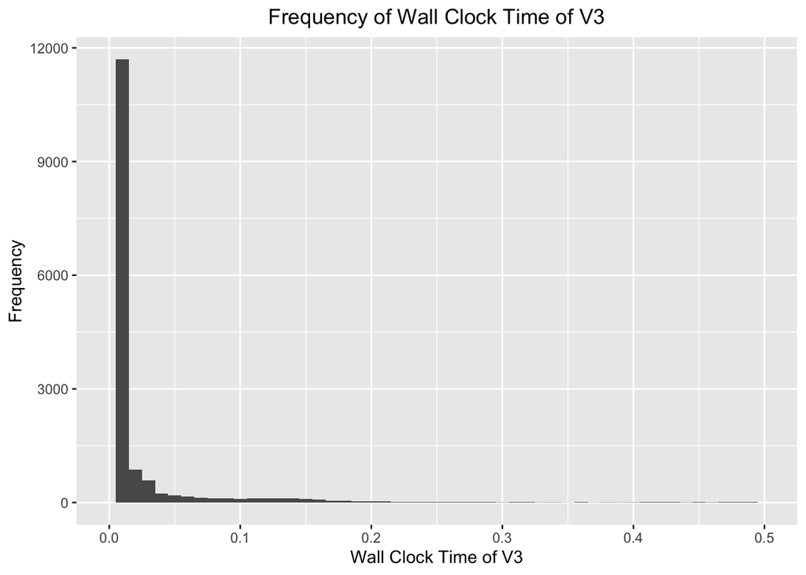

```r
# Here I set 0.5 as the upper bound of the xlim for this particular dataset
# It is not efficient
# From the plot, the real run time is highly right skewed for V3
ggplot(V3, aes(x=real)) +
  geom_histogram(binwidth=0.01) +
  labs(x = "Wall Clock Time of V3", y = "Frequency") +
  xlim(0, 0.5) +
  ggtitle("Frequency of Wall Clock Time of V3") +
  theme(plot.title = element_text(hjust = 0.5))
```

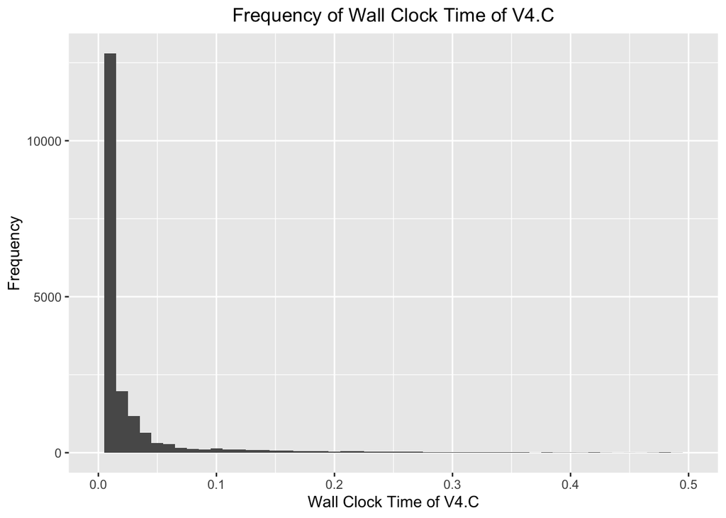

```r
# From the plot, the real run time is also highly right skewed for V4.C
# Compare to V3, the real run time increases compare to V3
ggplot(V4.C, aes(x=real)) +
  geom_histogram(binwidth=0.01) +
  labs(x = "Wall Clock Time of V4.C", y = "Frequency") +
  xlim(0, 0.5) +
  ggtitle("Frequency of Wall Clock Time of V4.C") +
  theme(plot.title = element_text(hjust = 0.5))
```

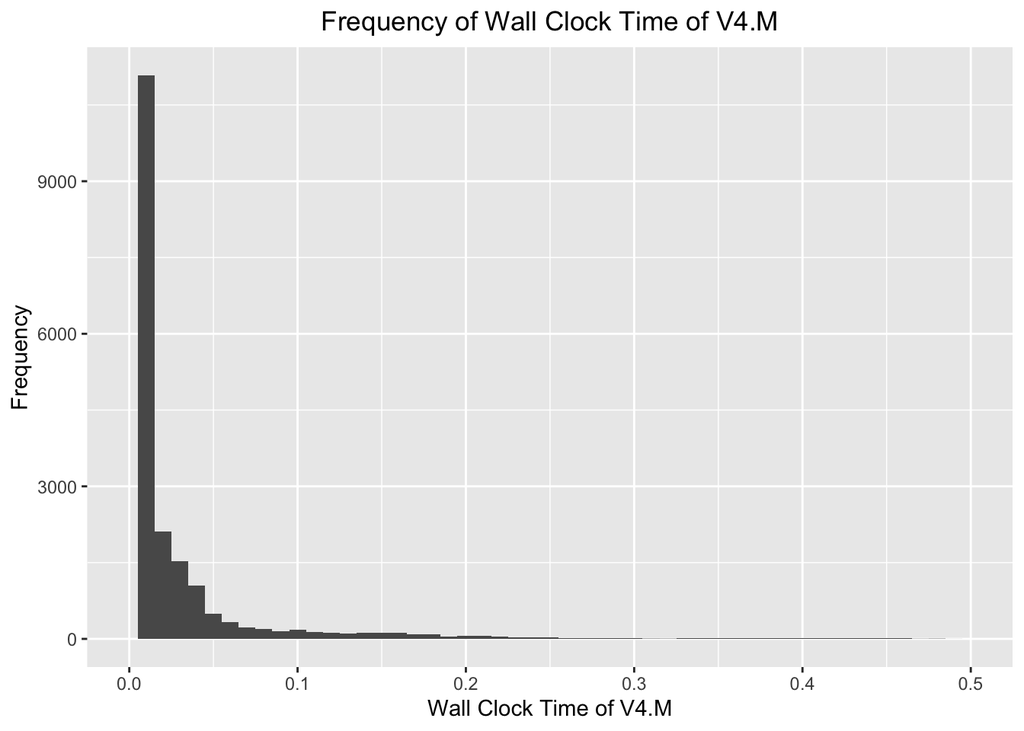

```r
# From the plot, the real run time is also hightly right skewed for V4.M
# Similar pattern like V4.C
ggplot(V4.M, aes(x=real)) +
  geom_histogram(binwidth=0.01) +
   labs(x = "Wall Clock Time of V4.M", y = "Frequency") +
  xlim(0, 0.5) +
  ggtitle("Frequency of Wall Clock Time of V4.M") +
  theme(plot.title = element_text(hjust = 0.5))
```

From the distribution, we can see the wall-clock time in all the systems are highly skewed. Therefore, it is not reasonable to see the the typical running time by mean since it is not normally distributed. We can look at the median instead to look at the typical running time. For V3, the median is 0.007s. For V4.C is 0.008, for V4.M is 0.01.

The result looks a bit award for me since the lastest version of system doesn’t beat the old version in wall-clock running time. Therefore, I should further investigate.

Let’s look at the worst and best case for each system

For V4.C, the best case for wall-clock time is 0.005s, the worst case is 15.997s. For cpu-time spent the best case is 0 and the worst case is 0.025. For kernel-time spent, the best case is 0 and the worst case is 0.011

For V4.M, the best case for wall-clock time is 0.005s, the worst case is 12.788s For cpu-time spent the best case is 0 and the worst case is 0.026. For kernel-time spent, the best case is 0 and the worst case is 0.011

From the summary statistic, we can see that the running time for real, cpu, and kernel for V4.C and V4.M are quite similar for best and wrost case. Something is a little but surprising is that V3 performs equally or better than V4.C and V4.M despite the worst case for wall-clock run time.

However, simply look at these is not convinced. We should try to look at the frequency for wall-clock time and percentage of how much cpu-time and user-time takes for wall-clock time.

Investigate wall-clock time first.

Use table command to do a summary statistics about the frequency of each time appears

```r
V3_real_freq <- data.frame(table(V3$real))
names(V3_real_freq)[1] <- "wall clock time"
V3_real_freq <- V3_real_freq[order(V3_real_freq$Freq, decreasing = TRUE), ]
V3_real_freq
```

|  | wall clock time | Freq |
| --- | --- | --- |
| 2 | 0.006 | 5343 |
| 1 | 0.005 | 3910 |
| 3 | 0.007 | 1453 |
| 4 | 0.008 | 1254 |
| 7 | 0.011 | 793 |
| 8 | 0.012 | 734 |
| 5 | 0.009 | 546 |
| 6 | 0.01 | 528 |
| 9 | 0.013 | 505 |
| 10 | 0.014 | 334 |

[output cut: 486 more lines]

```r
V4.C_real_freq <- data.frame(table(V4.C$real))
names(V4.C_real_freq)[1] <- "wall clock time"
V4.C_real_freq <- V4.C_real_freq[order(V4.C_real_freq$Freq, decreasing = TRUE), ]
V4.C_real_freq
```

|  | wall clock time | Freq |
| --- | --- | --- |
| 3 | 0.007 | 5731 |
| 2 | 0.006 | 2082 |
| 4 | 0.008 | 1854 |
| 10 | 0.014 | 848 |
| 11 | 0.015 | 681 |
| 9 | 0.013 | 628 |
| 12 | 0.016 | 445 |
| 5 | 0.009 | 432 |
| 13 | 0.017 | 296 |
| 8 | 0.012 | 233 |

[output cut: 746 more lines]

```r
V4.M_real_freq <- data.frame(table(V4.M$real))
names(V4.M_real_freq)[1] <- "wall clock time"
V4.M_real_freq <- V4.M_real_freq[order(V4.M_real_freq$Freq, decreasing = TRUE), ]
V4.M_real_freq
```

|  | wall clock time | Freq |
| --- | --- | --- |
| 2 | 0.006 | 3536 |
| 3 | 0.007 | 2810 |
| 4 | 0.008 | 1697 |
| 5 | 0.009 | 923 |
| 6 | 0.01 | 621 |
| 7 | 0.011 | 435 |
| 8 | 0.012 | 379 |
| 9 | 0.013 | 265 |
| 17 | 0.021 | 264 |
| 16 | 0.02 | 250 |

[output cut: 747 more lines]

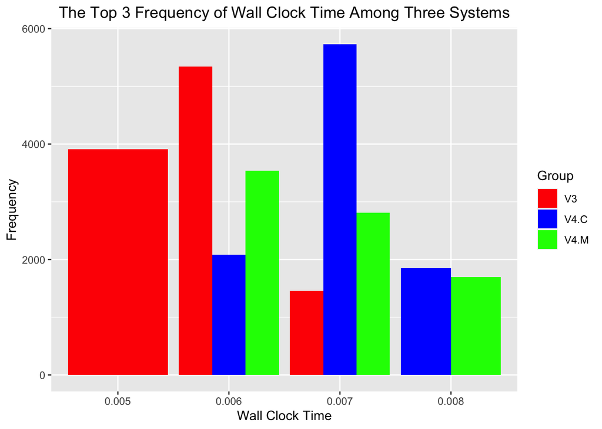

```r
# Create the dataset with three groups only contains head three rows
V3_head3 <- data.frame(head(V3_real_freq, n = 3), group = "V3")
V4.C_head3 <- data.frame(head(V4.C_real_freq, n = 3),  group = "V4.C")
V4.M_head3 <- data.frame(head(V4.M_real_freq, n = 3),  group = "V4.M")
head3 <- rbind(V3_head3, V4.C_head3, V4.M_head3)
# Create the histogram with three groups
# Here might be a bit confuseing, since I rank top 3 frequency
#Still trying to fix this by making each binsize identical
ggplot(data = head3, aes(x = wall.clock.time, y = Freq, fill = group)) +
  geom_histogram(stat = "identity", position = "dodge") +
  scale_fill_manual(values = c("red", "blue", "green")) +
  labs(x = "Wall Clock Time", y = "Frequency", fill = "Group") +
  ggtitle("The Top 3 Frequency of Wall Clock Time Among Three Systems") +
  theme(plot.title = element_text(hjust = 0.5))
```

From each summary table, we can see that the most frequent wall-clock time for V3 is 0.006s, for V4.C is 0.007s, for V4.M is 0.006s.

From the plot, it is very intuitive to see V3 is has the advantages in real wall-clock time

This kind of match what we discover in previous summary statistic.

```r
V3_desc_time <- V3_real_freq[order(V3_real_freq$`wall clock time`), ]
V3_desc_time
```

|  | wall clock time | Freq |
| --- | --- | --- |
| 1 | 0.005 | 3910 |
| 2 | 0.006 | 5343 |
| 3 | 0.007 | 1453 |
| 4 | 0.008 | 1254 |
| 5 | 0.009 | 546 |
| 6 | 0.01 | 528 |
| 7 | 0.011 | 793 |
| 8 | 0.012 | 734 |
| 9 | 0.013 | 505 |
| 10 | 0.014 | 334 |

[output cut: 486 more lines]

```r
V4.C_desc_time <- V4.C_real_freq[order(V4.C_real_freq$`wall clock time`), ]
V4.C_desc_time
```

|  | wall clock time | Freq |
| --- | --- | --- |
| 1 | 0.005 | 43 |
| 2 | 0.006 | 2082 |
| 3 | 0.007 | 5731 |
| 4 | 0.008 | 1854 |
| 5 | 0.009 | 432 |
| 6 | 0.01 | 167 |
| 7 | 0.011 | 146 |
| 8 | 0.012 | 233 |
| 9 | 0.013 | 628 |
| 10 | 0.014 | 848 |

[output cut: 746 more lines]

```r
V4.M_desc_time <- V4.M_real_freq[order(V4.M_real_freq$`wall clock time`), ]
V4.M_desc_time
```

|  | wall clock time | Freq |
| --- | --- | --- |
| 1 | 0.005 | 142 |
| 2 | 0.006 | 3536 |
| 3 | 0.007 | 2810 |
| 4 | 0.008 | 1697 |
| 5 | 0.009 | 923 |
| 6 | 0.01 | 621 |
| 7 | 0.011 | 435 |
| 8 | 0.012 | 379 |
| 9 | 0.013 | 265 |
| 10 | 0.014 | 217 |

[output cut: 747 more lines]

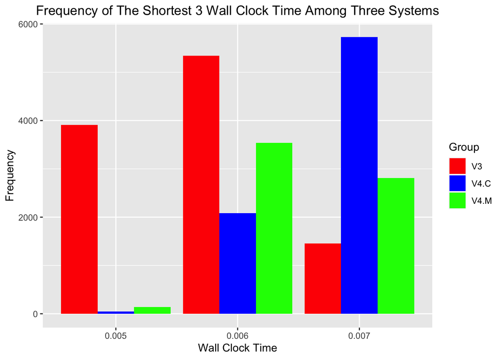

```r
# Create the dataset with three groups only contains head three rows
V3_time_head3 <- data.frame(head(V3_desc_time, n = 3), group = "V3")
V4.C_time_head3 <- data.frame(head(V4.C_desc_time, n = 3),  group = "V4.C")
V4.M_time_head3 <- data.frame(head(V4.M_desc_time, n = 3),  group = "V4.M")
head3_time <- rbind(V3_time_head3, V4.C_time_head3, V4.M_time_head3)
# Create the histogram with three groups
ggplot(data = head3_time, aes(x = head3_time$wall.clock.time, y = head3_time$Freq, fill = group)) +
  geom_histogram(stat = "identity", position = "dodge") +
  scale_fill_manual(values = c("red", "blue", "green")) +
  labs(x = "Wall Clock Time", y = "Frequency", fill = "Group") +
  ggtitle("Frequency of The Shortest 3 Wall Clock Time Among Three Systems") +
  theme(plot.title = element_text(hjust = 0.5))
```

This table also shows that the requency of min wall-clock time for V3 is the most among the three systems.

The plot also shows for differnet V3 has advantages in wall-clock time.

We can seperate the wall-clock time in several range, 0-0.05, 0.051-0.1, 0.101 - 0.5, >0.5

First, do it for V3, then for V4.C and V4.M

The time interval here is subjective to change, I just randomly pick what I think makes sense here

#V3

```r
V3_real_freq$`wall clock time` <- as.numeric(as.character(V3_real_freq$`wall clock time`))

# Filter rows where wall clock time is between 0 and 0.05 and calculate sum of Freq column
V3_sum_freq_0.05 <- sum(subset
                        (V3_real_freq, V3_real_freq$"wall clock time" >= 0 &
                            V3_real_freq$"wall clock time" <= 0.05)$Freq)

# Filter rows where wall clock time is between 0.051 and 0.1 and calculate sum of Freq column
V3_sum_freq_0.1 <- sum(subset
                        (V3_real_freq, V3_real_freq$"wall clock time" >= 0.051 &
                            V3_real_freq$"wall clock time" <= 0.1)$Freq)

# Filter rows where wall clock time is between 0.101 and 0.5 and calculate sum of Freq column
V3_sum_freq_0.5 <- sum(subset
                         (V3_real_freq, V3_real_freq$"wall clock time" >= 0.101 &
                             V3_real_freq$"wall clock time" <= 0.5)$Freq)

# Filter rows where wall clock time is greater than 0.5 and calculate sum of Freq column
V3_sum_freq_0.501 <- sum(subset(V3_real_freq, V3_real_freq$"wall clock time" >= 0.501)$Freq)

V3_freq <- data.frame(col1 = c("0 and 0.05", "0.051 and 0.1",
                               "0.101 and 0.5", "0.501 and greater"),
                      col2 = c(V3_sum_freq_0.05, V3_sum_freq_0.1,
                               V3_sum_freq_0.5, V3_sum_freq_0.501))
names(V3_freq)[1] <- " Time Interval"
names(V3_freq)[2] <- "Frequency"
V3_freq <- data.frame(V3_freq,  group = "V3")
```

# V4.C

```r
V4.C_real_freq$`wall clock time` <- as.numeric(as.character(V4.C_real_freq$`wall clock time`))

# Filter rows where wall clock time is between 0 and 0.05 and calculate sum of Freq column
V4.C_sum_freq_0.05 <- sum(subset
                        (V4.C_real_freq, V4.C_real_freq$"wall clock time" >= 0 &
                            V4.C_real_freq$"wall clock time" <= 0.05)$Freq)

# Filter rows where wall clock time is between 0.051 and 0.1 and calculate sum of Freq column
V4.C_sum_freq_0.1 <- sum(subset
                        (V4.C_real_freq, V4.C_real_freq$"wall clock time" >= 0.051 &
                            V4.C_real_freq$"wall clock time" <= 0.1)$Freq)

# Filter rows where wall clock time is between 0.101 and 0.5 and calculate sum of Freq column
V4.C_sum_freq_0.5 <- sum(subset
                         (V4.C_real_freq, V4.C_real_freq$"wall clock time" >= 0.101 &
                             V4.C_real_freq$"wall clock time" <= 0.5)$Freq)

# Filter rows where wall clock time is greater than 0.5 and calculate sum of Freq column
V4.C_sum_freq_0.501 <- sum(subset(V4.C_real_freq, V4.C_real_freq$"wall clock time" >= 0.501)$Freq)

V4.C_freq <- data.frame(col1 = c("0 and 0.05", "0.051 and 0.1",
                               "0.101 and 0.5", "0.501 and greater"),
                      col2 = c(V4.C_sum_freq_0.05, V4.C_sum_freq_0.1,
                               V4.C_sum_freq_0.5, V4.C_sum_freq_0.501))
names(V4.C_freq)[1] <- " Time Interval"
names(V4.C_freq)[2] <- "Frequency"
V4.C_freq <- data.frame(V4.C_freq,  group = "V4.C")
```

# V4.M

```r
V4.M_real_freq$`wall clock time` <- as.numeric(as.character(V4.M_real_freq$`wall clock time`))

# Filter rows where wall clock time is between 0 and 0.05 and calculate sum of Freq column
V4.M_sum_freq_0.05 <- sum(subset
                        (V4.M_real_freq, V4.M_real_freq$"wall clock time" >= 0 &
                            V4.M_real_freq$"wall clock time" <= 0.05)$Freq)

# Filter rows where wall clock time is between 0.051 and 0.1 and calculate sum of Freq column
V4.M_sum_freq_0.1 <- sum(subset
                        (V4.M_real_freq, V4.M_real_freq$"wall clock time" >= 0.051 &
                            V4.M_real_freq$"wall clock time" <= 0.1)$Freq)

# Filter rows where wall clock time is between 0.101 and 0.5 and calculate sum of Freq column
V4.M_sum_freq_0.5 <- sum(subset
                         (V4.M_real_freq, V4.M_real_freq$"wall clock time" >= 0.101 &
                             V4.M_real_freq$"wall clock time" <= 0.5)$Freq)

# Filter rows where wall clock time is greater than 0.5 and calculate sum of Freq column
V4.M_sum_freq_0.501 <- sum(subset(V4.M_real_freq, V4.M_real_freq$"wall clock time" >= 0.501)$Freq)

V4.M_freq <- data.frame(col1 = c("0 and 0.05", "0.051 and 0.1",
                               "0.101 and 0.5", "0.501 and greater"),
                      col2 = c(V4.M_sum_freq_0.05, V4.M_sum_freq_0.1,
                               V4.M_sum_freq_0.5, V4.M_sum_freq_0.501))
names(V4.M_freq)[1] <- " Time Interval"
names(V4.M_freq)[2] <- "Frequency"
V4.M_freq <- data.frame(V4.M_freq,  group = "V4.M")
```

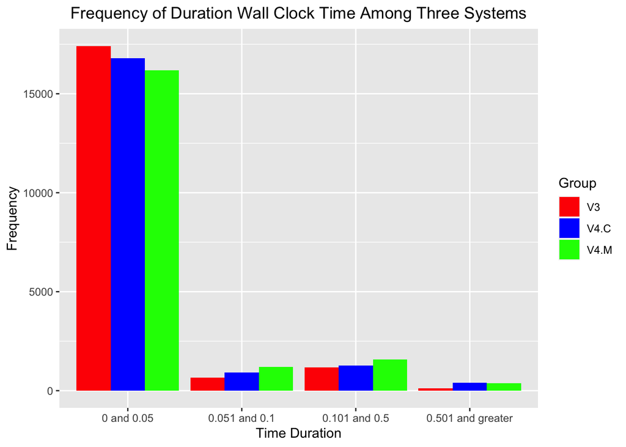

```r
duration <- rbind(V3_freq, V4.C_freq, V4.M_freq)
# Create the histogram with three groups
ggplot(data = duration, aes(x = duration$X.Time.Interval, y = duration$Frequency, fill = group)) +
  geom_histogram(stat = "identity", position = "dodge") +
  scale_fill_manual(values = c("red", "blue", "green")) +
  labs(x = "Time Duration", y = "Frequency", fill = "Group") +
  ggtitle("Frequency of Duration Wall Clock Time Among Three Systems") +
  theme(plot.title = element_text(hjust = 0.5))
```

This plot also matches what we find in previous plot and table. However, there is another pattern that duration from 0.051, the V4.M seems took longer than V3 and V4.C.

Here, we are done with analyzing real time

###########################Now, let’s analyze the cpu run time and kernel run time.##################################

```r
# Loop through each row of the dataset
for (i in 1:nrow(V3)) {
  # Calculate percentage of cputime/realtime and add as a new column
  V3$cputime_percent[i] <- V3$user[i] / V3$real[i] * 100

  # Calculate percentage of kerneltime/realtime and add as a new column
  V3$kerneltime_percent[i] <- V3$sys[i] / V3$real[i] * 100

  # Replace NA values with 0
  V3$cputime_percent[i] <- ifelse(is.na(V3$cputime_percent[i]), 0, V3$cputime_percent[i])
  V3$kerneltime_percent[i] <- ifelse(is.na(V3$kerneltime_percent[i]), 0, V3$kerneltime_percent[i])
}

V3_perc <- V3


#For V4.C
# Loop through each row of the dataset
for (i in 1:nrow(V4.C)) {
  # Calculate percentage of cputime/realtime and add as a new column
  V4.C$cputime_percent[i] <- V4.C$user[i] / V4.C$real[i] * 100

  # Calculate percentage of kerneltime/realtime and add as a new column
  V4.C$kerneltime_percent[i] <- V4.C$sys[i] / V4.C$real[i] * 100

  # Replace NA values with 0
  V4.C$cputime_percent[i] <- ifelse(is.na(V4.C$cputime_percent[i]), 0, V4.C$cputime_percent[i])
  V4.C$kerneltime_percent[i] <- ifelse(is.na(V4.C$kerneltime_percent[i]), 0, V4.C$kerneltime_percent[i])
}

V4.C_perc <- V4.C

# Loop through each row of the dataset
for (i in 1:nrow(V4.M)) {
  # Calculate percentage of cputime/realtime and add as a new column
  V4.M$cputime_percent[i] <- V4.M$user[i] / V4.M$real[i] * 100

  # Calculate percentage of kerneltime/realtime and add as a new column
  V4.M$kerneltime_percent[i] <- V4.M$sys[i] / V4.M$real[i] * 100

  # Replace NA values with 0
  V4.M$cputime_percent[i] <- ifelse(is.na(V4.M$cputime_percent[i]), 0, V4.M$cputime_percent[i])
  V4.M$kerneltime_percent[i] <- ifelse(is.na(V4.M$kerneltime_percent[i]), 0, V4.M$kerneltime_percent[i])
}

V4.M_perc <- V4.M
```

```r
# summary(V3_perc)
# summary(V4.C_perc)
# summary(V4.M_perc)
```

# The CPU run time for V3

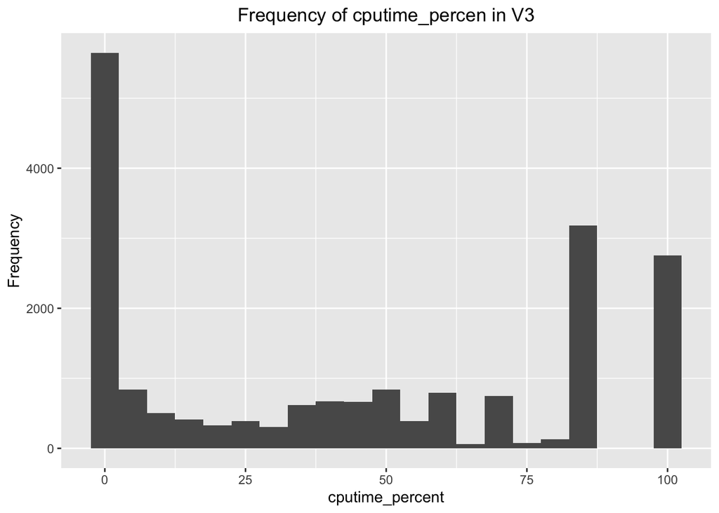

```r
# From the plot, the real run time is highly right skewed for V3
ggplot(V3_perc, aes(x=cputime_percent)) +
  geom_histogram(binwidth=5) +
  labs(x = "cputime_percent", y = "Frequency") +
  ggtitle("Frequency of cputime_percen in V3") +
  theme(plot.title = element_text(hjust = 0.5))
```

# The CPU run time for V4.C

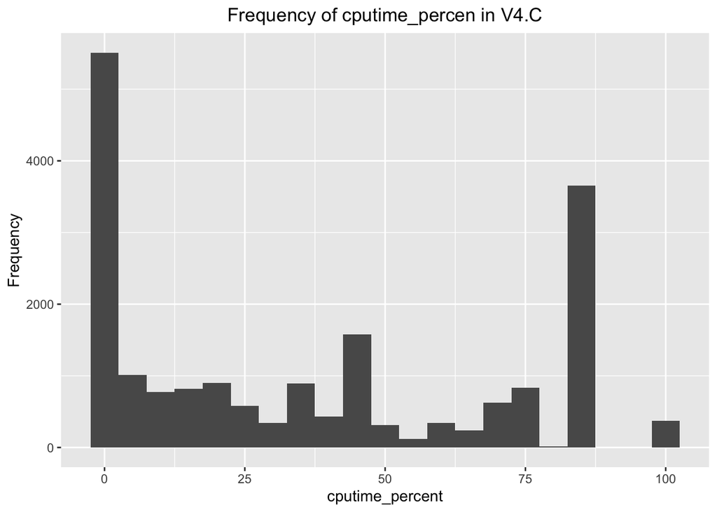

```r
# From the plot, the real run time is highly right skewed for V4.C
ggplot(V4.C_perc, aes(x=cputime_percent)) +
  geom_histogram(binwidth=5) +
  labs(x = "cputime_percent", y = "Frequency") +
  ggtitle("Frequency of cputime_percen in V4.C") +
  theme(plot.title = element_text(hjust = 0.5))
```

#The CPU Run time for V4.M

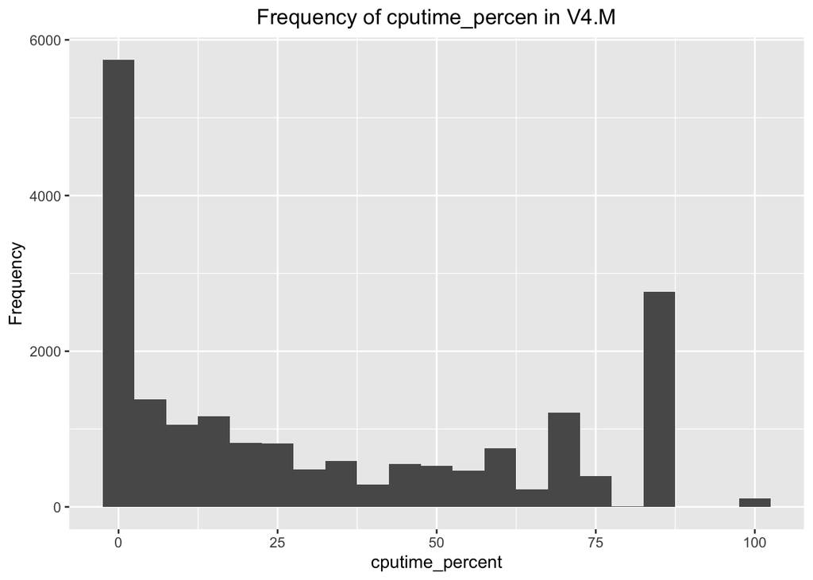

```r
# From the plot, the real run time is highly right skewed for V4.M
ggplot(V4.M_perc, aes(x=cputime_percent)) +
  geom_histogram(binwidth=5) +
  labs(x = "cputime_percent", y = "Frequency") +
  ggtitle("Frequency of cputime_percen in V4.M") +
  theme(plot.title = element_text(hjust = 0.5))
```

# The Kernel Run Time for V3

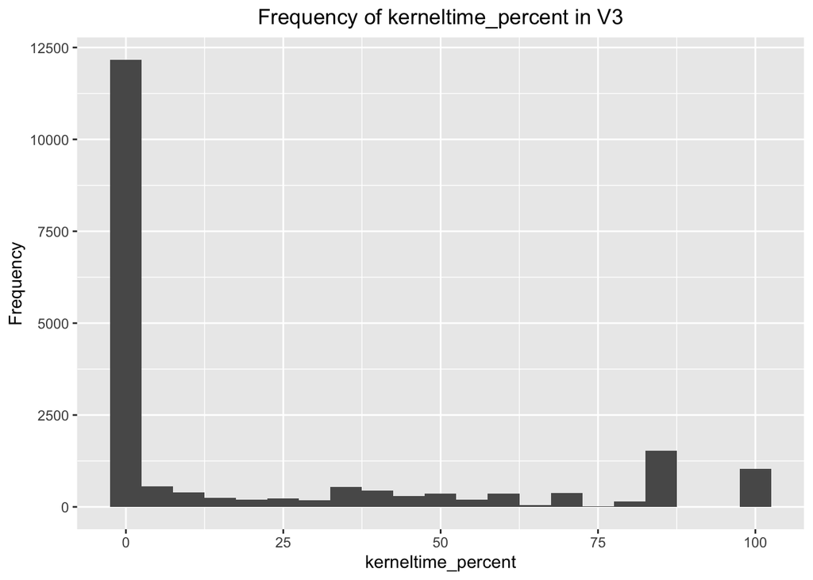

```r
# From the plot, the real run time is highly right skewed for V3
ggplot(V3_perc, aes(x=kerneltime_percent)) +
  geom_histogram(binwidth=5) +
  labs(x = "kerneltime_percent", y = "Frequency") +
  ggtitle("Frequency of kerneltime_percent in V3") +
  theme(plot.title = element_text(hjust = 0.5))
```

# The Kernel Run Time for V4.C

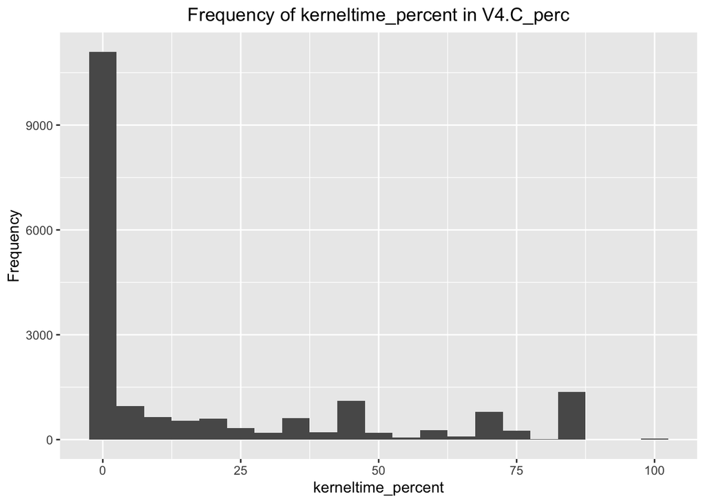

```r
# From the plot, the real run time is highly right skewed for V4.C_perc
ggplot(V4.C_perc, aes(x=kerneltime_percent)) +
  geom_histogram(binwidth=5) +
  labs(x = "kerneltime_percent", y = "Frequency") +
  ggtitle("Frequency of kerneltime_percent in V4.C_perc") +
  theme(plot.title = element_text(hjust = 0.5))
```

# The Kernel Run Time For V4.M

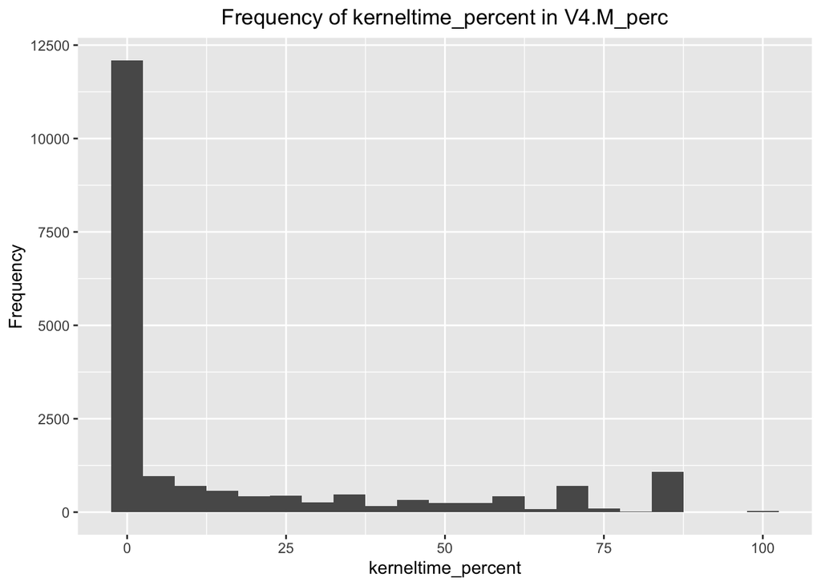

```r
# From the plot, the real run time is highly right skewed for V3
ggplot(V4.M_perc, aes(x=kerneltime_percent)) +
  geom_histogram(binwidth=5) +
  labs(x = "kerneltime_percent", y = "Frequency") +
  ggtitle("Frequency of kerneltime_percent in V4.M_perc") +
  theme(plot.title = element_text(hjust = 0.5))
```

It is really hard to compare separately. It is better to use a conditional violin plot.

Create a new dataset contains all of the cpu and kernel run time with respect to different systems.

```r
# Select the last two columns which is cpu run time perc and kernel run time perc
V3_cpu <- data.frame(V3_perc[, (ncol(V3_perc)-1)], group = "V3 CPU")
names(V3_cpu)[1] <- "run_time_perc"
V3_kernel <- data.frame(V3_perc[, (ncol(V3_perc))], group = "V3 Kernel")
names(V3_kernel)[1] <- "run_time_perc"

V4.C_cpu <- data.frame(V4.C_perc[, (ncol(V4.C_perc)-1)], group = "V4.C CPU")
names(V4.C_cpu)[1] <- "run_time_perc"
V4.C_kernel <- data.frame(V4.C_perc[, (ncol(V4.C_perc))], group = "V4.C Kernel")
names(V4.C_kernel)[1] <- "run_time_perc"

V4.M_cpu <- data.frame(V4.M_perc[, (ncol(V4.M_perc)-1)], group = "V4.M CPU")
names(V4.M_cpu)[1] <- "run_time_perc"
V4.M_kernel <- data.frame(V4.M_perc[, (ncol(V4.M_perc))], group = "V4.M Kernel")
names(V4.M_kernel)[1] <- "run_time_perc"

# Combine all the previous data frame to make a big data set contains all the cpu kernel run time for three systems
perc <- rbind(V3_cpu, V3_kernel, V4.C_cpu, V4.C_kernel, V4.M_cpu, V4.M_kernel)
```

# Draw a facet histogram

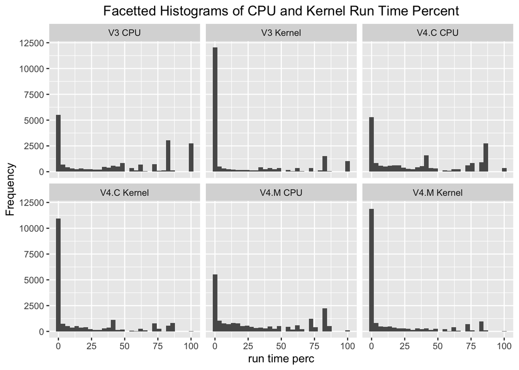

```r
perc %>%
  ggplot(aes(x = run_time_perc)) +
  geom_histogram()+
  labs(x = "run time perc",
       y = "Frequency",
       title = "Facetted Histograms of CPU and Kernel Run Time Percent")+
  facet_wrap(~ group)+
  theme(plot.title = element_text(hjust = 0.5))
```

It is a little bit easier to observe and compare.

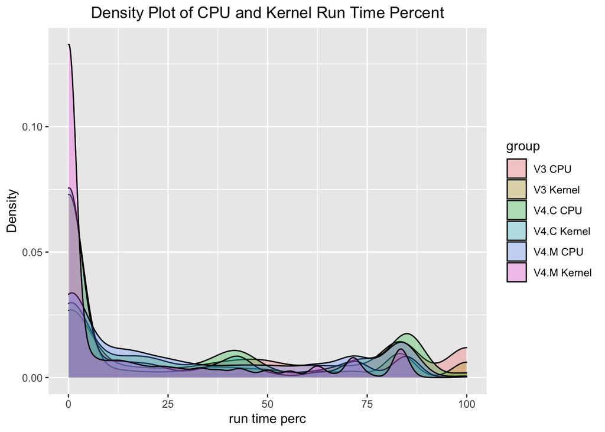

```r
#
perc %>%
  ggplot(aes(x = run_time_perc)) +
  geom_density(aes(fill = group),
               alpha = .3)+
  labs(x = "run time perc",
       y = "Density",
       title = "Density Plot of CPU and Kernel Run Time Percent")+
  theme(plot.title = element_text(hjust = 0.5))
```

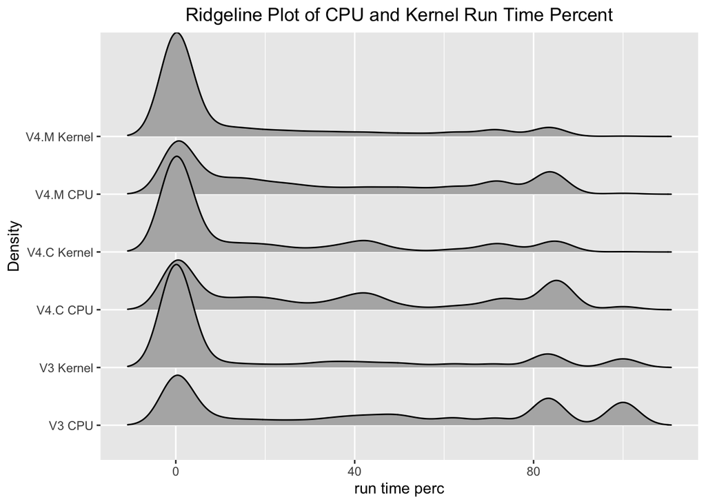

```r
perc %>%
  ggplot(aes(x = run_time_perc,
             y = group)) +
  geom_density_ridges()+
  labs(x = "run time perc",
       y = "Density",
       title = "Ridgeline Plot of CPU and Kernel Run Time Percent")+
  theme(plot.title = element_text(hjust = 0.5))
```

From the ridgeline plot, we can also observe that the V3 has a deficiency in cpu run time since it has two peak after 80% percent while V4.C and V4.M only have one.

Also, we can observe that the density of V4.M in cpu runs time also is flatter than V4.C and V3.

Overall, we can assume that V4.M has an overall advantage of cpu run time and kernel run time.

#####################It could be end of the cpu and kernel run time analysis in a big picture#########################

The previous analysis is based on the whole dataset regardless of the number of rows that returned.

It is also reasonable to separate the data into query that returns row and returns none

# Make seperate dataset that query returns something and none

```r
# If rows = 0, the query returns nothing
V3_none <- subset(V3, V3$rows == 0)
V4.C_none <- subset(V4.C, V4.C$rows == 0)
V4.M_none <- subset(V4.M, V4.M$rows == 0)

# If rows !=0, the query returns at least one row
V3_return <- subset(V3, V3$rows != 0)
V4.C_return <- subset(V4.C, V4.C$rows != 0)
V4.M_return <- subset(V4.M, V4.M$rows != 0)
```

Now, we have six different datasets that each systems file are divided into returns 0 row or at least 1 row

We could do something simple at first place, we could draw a pie chart

```r
# Each run time for V3 that nothing return
V3_none_sumreal <- sum(V3_none$real)
V3_none_sumcpu <- sum(V3_none$user)
V3_none_sumker <- sum(V3_none$sys)

# Each run time for V4.C that nothing return
V4.C_none_sumreal <- sum(V4.C_none$real)
V4.C_none_sumcpu <- sum(V4.C_none$user)
V4.C_none_sumker <- sum(V4.C_none$sys)

# Each run time for V4.M that nothing return
V4.M_none_sumreal <- sum(V4.M_none$real)
V4.M_none_sumcpu <- sum(V4.M_none$user)
V4.M_none_sumker <- sum(V4.M_none$sys)
```

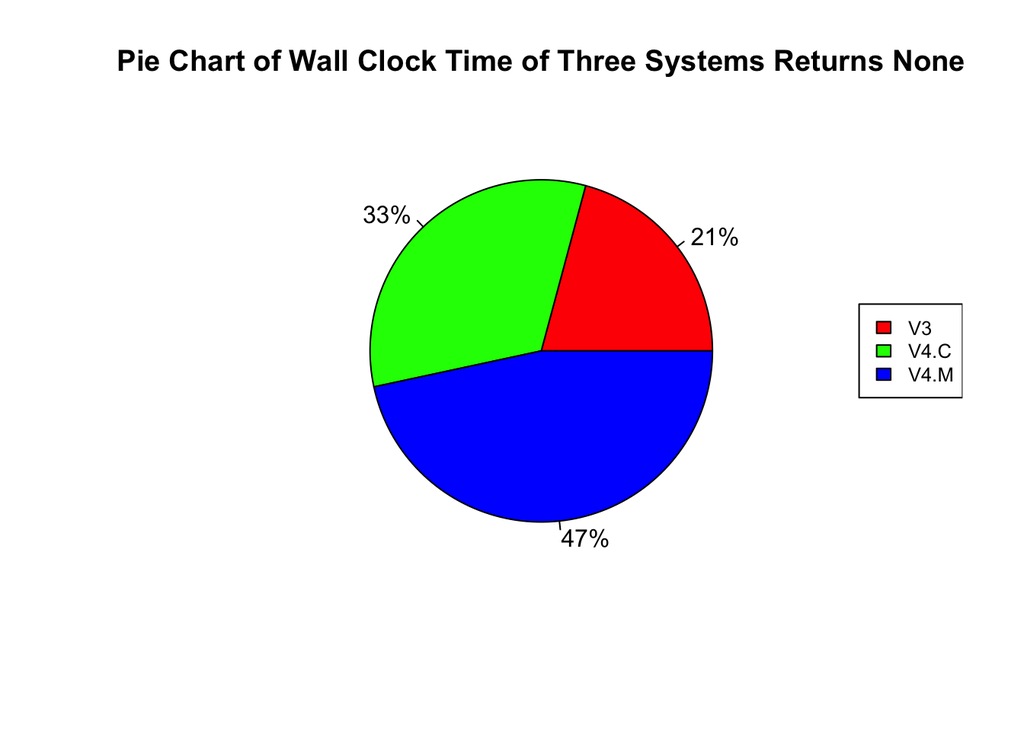

```r
# create a vector with sum of wall-clock time to plot
sumreal <- c(V3_none_sumreal, V4.C_none_sumreal, V4.M_none_sumreal)
# create a vector with labels for each value
labels <- c("V3", "V4.C", "V4.M")
# create a pie chart with default colors
pie(sumreal, labels = percent(sumreal/sum(sumreal)),
    main = "Pie Chart of Wall Clock Time of Three Systems Returns None", col = rainbow(length(sumreal)))
# add a legend to the chart
legend("right", legend = labels, cex = 0.8, fill = rainbow(length(sumreal)))
```

From the pie chart, we can see that V4.M is has the most wall clock run time among the three and V3 has the least for not returning anything.

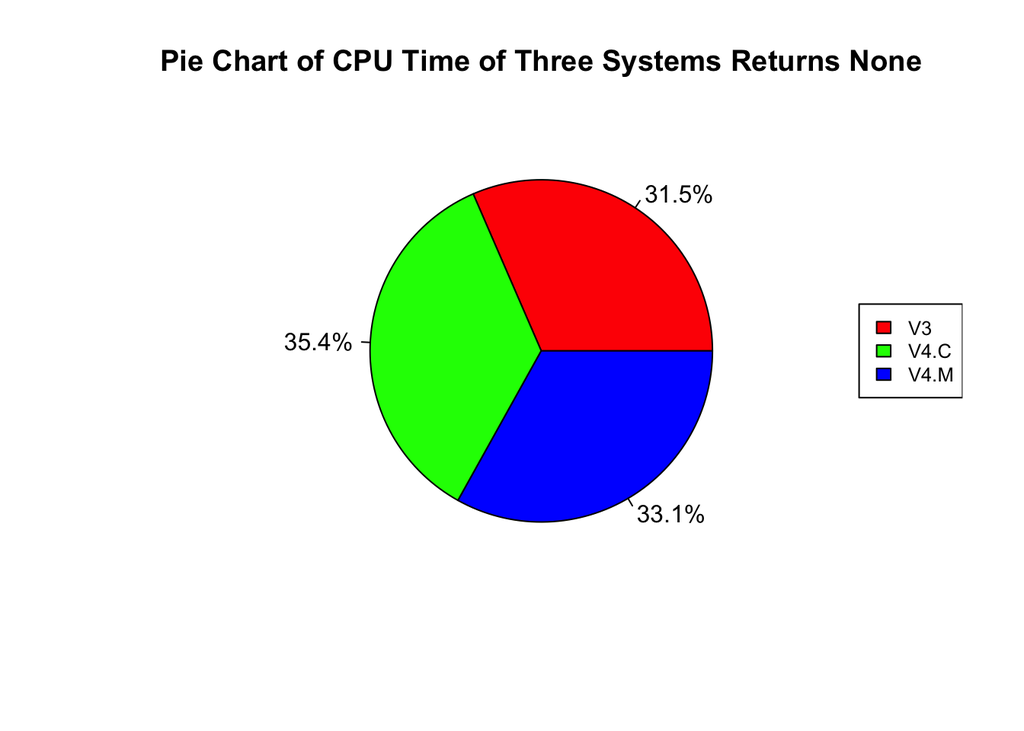

```r
# create a vector with sum of cpu run time to plot
sumcpu <- c(V3_none_sumcpu, V4.C_none_sumcpu, V4.M_none_sumcpu)
# create a vector with labels for each value
labels <- c("V3", "V4.C", "V4.M")
# create a pie chart with default colors
pie(sumcpu, labels = percent(sumcpu/sum(sumcpu)),
    main = "Pie Chart of CPU Time of Three Systems Returns None", col = rainbow(length(sumcpu)))
# add a legend to the chart
legend("right", legend = labels, cex = 0.8, fill = rainbow(length(sumcpu)))
```

For three systems that returns nothing, we can clearly see that each systems has approximately same cpu run time, the V3 has a little bit advantages. V4.C has the most cpu runs time,

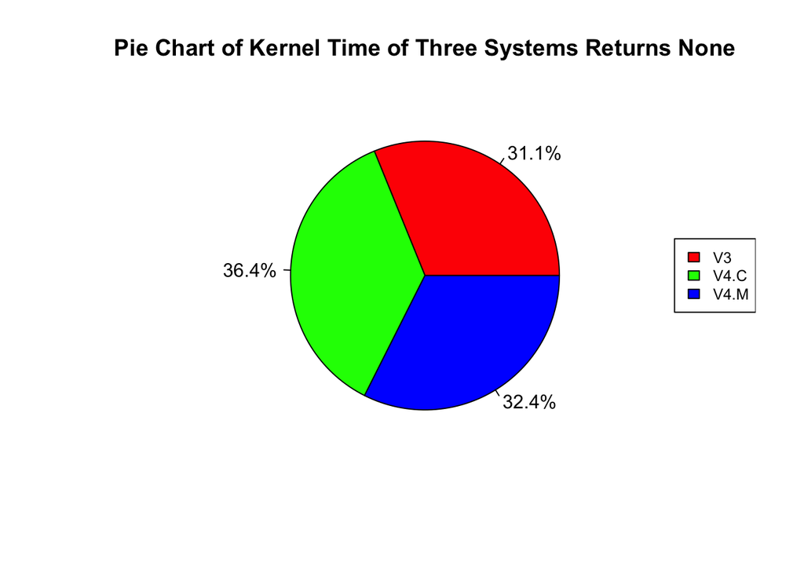

```r
# create a vector with sum of kernel run time to plot
sumker <- c(V3_none_sumker, V4.C_none_sumker, V4.M_none_sumker)
# create a vector with labels for each value
labels <- c("V3", "V4.C", "V4.M")
# create a pie chart with default colors
pie(sumker, labels = percent(sumker/sum(sumker)),
    main = "Pie Chart of Kernel Time of Three Systems Returns None", col = rainbow(length(sumker)))
# add a legend to the chart
legend("right", legend = labels, cex = 0.8, fill = rainbow(length(sumker)))
```

The kernel runs time shows a similar pattern like cpu runs time. V4.C has the most and V3 has the least.

# What about returns at least one row

```r
# Each run time for V3 that something return
V3_return_sumreal <- sum(V3_return$real)
V3_return_sumcpu <- sum(V3_return$user)
V3_return_sumker <- sum(V3_return$sys)

# Each run time for V4.C that something return
V4.C_return_sumreal <- sum(V4.C_return$real)
V4.C_return_sumcpu <- sum(V4.C_return$user)
V4.C_return_sumker <- sum(V4.C_return$sys)

# Each run time for V4.M that something return
V4.M_return_sumreal <- sum(V4.M_return$real)
V4.M_return_sumcpu <- sum(V4.M_return$user)
V4.M_return_sumker <- sum(V4.M_return$sys)
```

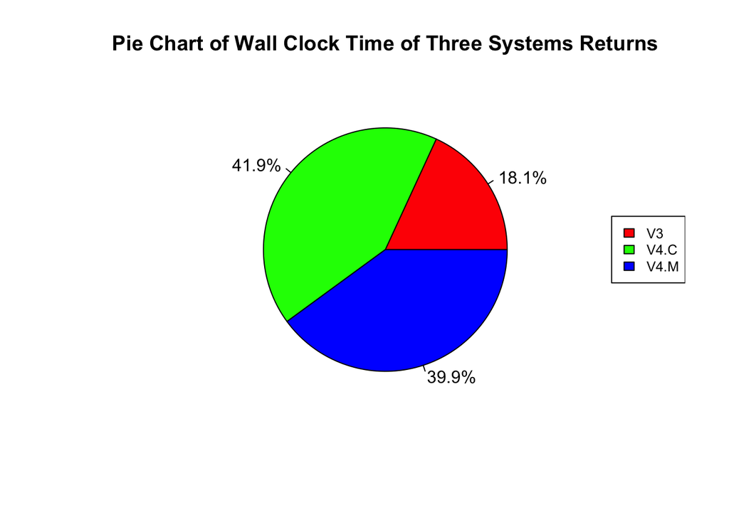

```r
# create a vector with sum of wall-clock time to plot
sumreal <- c(V3_return_sumreal, V4.C_return_sumreal, V4.M_return_sumreal)
# create a vector with labels for each value
labels <- c("V3", "V4.C", "V4.M")
# create a pie chart with default colors
pie(sumreal, labels = percent(sumreal/sum(sumreal)),
    main = "Pie Chart of Wall Clock Time of Three Systems Returns", col = rainbow(length(sumreal)))
# add a legend to the chart
legend("right", legend = labels, cex = 0.8, fill = rainbow(length(sumreal)))
```

For query that has something return, the result is quite different. V4.C takes much longer than other V3 and class to V4.M. For wall-clock time, it seems like V3 is very efficient for query that has something return.

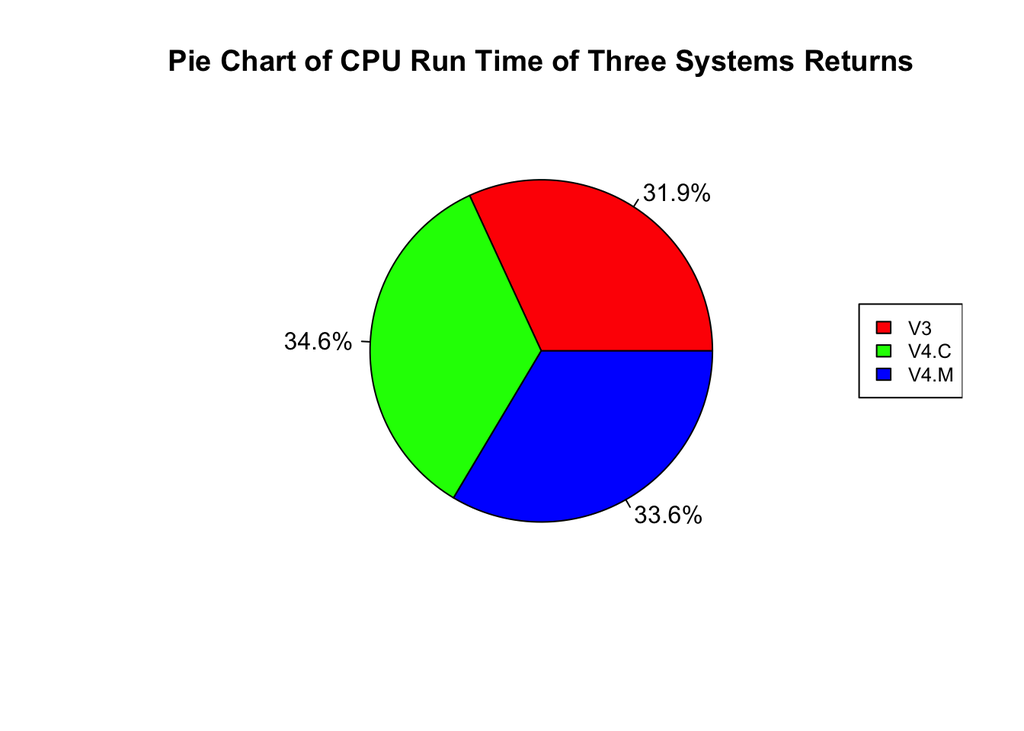

```r
# create a vector with sum of cpu run time to plot
sumcpu <- c(V3_return_sumcpu, V4.C_return_sumcpu, V4.M_return_sumcpu)
# create a vector with labels for each value
labels <- c("V3", "V4.C", "V4.M")
# create a pie chart with default colors
pie(sumcpu, labels = percent(sumcpu/sum(sumcpu)),
    main = "Pie Chart of CPU Run Time of Three Systems Returns", col = rainbow(length(sumcpu)))
# add a legend to the chart
legend("right", legend = labels, cex = 0.8, fill = rainbow(length(sumcpu)))
```

For CPU runs time, each system shows consistency of running time on cpu

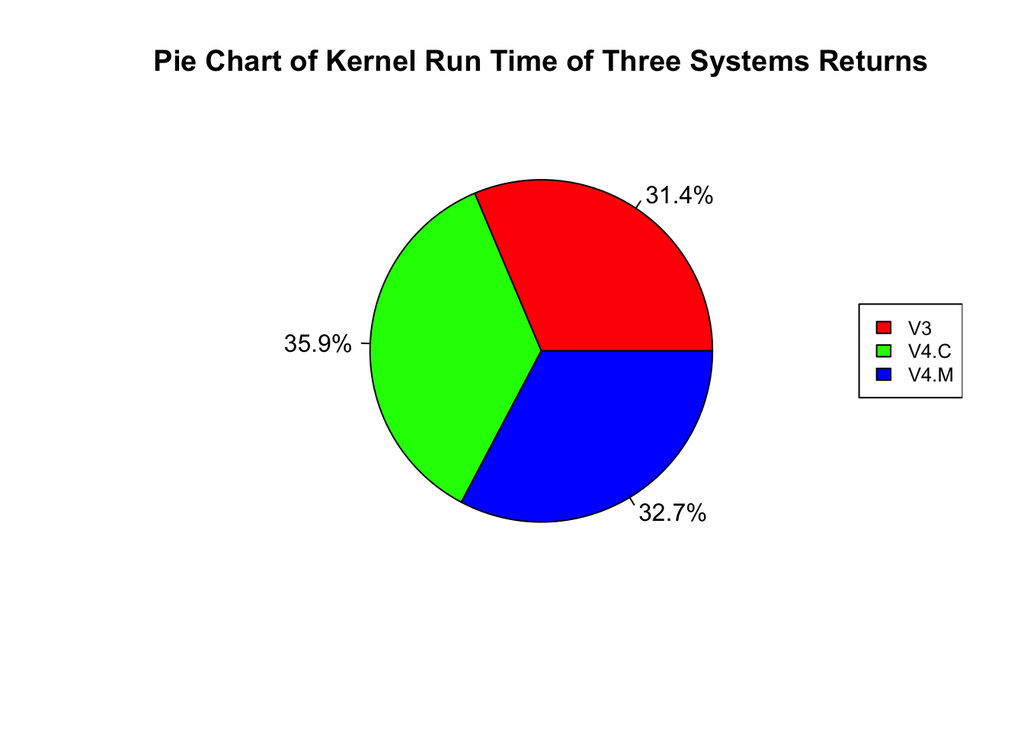

```r
# create a vector with sum of wall-clock time to plot
sumker <- c(V3_return_sumker, V4.C_return_sumker, V4.M_return_sumker)
# create a vector with labels for each value
labels <- c("V3", "V4.C", "V4.M")
# create a pie chart with default colors
pie(sumker, labels = percent(sumker/sum(sumker)),
    main = "Pie Chart of Kernel Run Time of Three Systems Returns", col = rainbow(length(sumker)))
# add a legend to the chart
legend("right", legend = labels, cex = 0.8, fill = rainbow(length(sumker)))
```

For the kernel run time for something returned, it also shows a consistency amont three systems.

**[We could repeat the whole process for the seperate dataset that returns one or none by copying what we did for the entire dataset. However, I wouldn’t do it here since it is time consuming, but by doing so, I’m pretty sure there will be something interesting.]**

###################################End of returns soemthing or none analysis#########################################

# Here, we could do pairwise comparison among three systems

```r
V3_time <- V3[, 2:4]
# Change the colum name into V3 so that it doesn't get confused
names(V3_time)[1] <- "V3_real"
names(V3_time)[2] <- "V3_user"
names(V3_time)[3] <- "V3_sys"


V4.C_time <- V4.C[, 2:4]
# Change the colum name into V3 so that it doesn't get confused
names(V4.C_time)[1] <- "V4.C_real"
names(V4.C_time)[2] <- "V4.C_user"
names(V4.C_time)[3] <- "V4.C_sys"


V4.M_time <- V4.M[, 2:4]
# Change the colum name into V4.M so that it doesn't get confused
names(V4.M_time)[1] <- "V4.M_real"
names(V4.M_time)[2] <- "V4.M_user"
names(V4.M_time)[3] <- "V4.M_sys"

# Create a dataset for pairwise comparesion

pairwise <- cbind(V3_time, V4.C_time, V4.M_time)
```

We could write an for loop to loop through each row and see for each real, cpu, sys, who is the shortest time.

We don’t need to use percentage here since we know we are comparing the same query every time

```r
# create variables to store counts
V3_real_count <- 0
V4.C_real_count <- 0
V4.M_real_count <- 0

V3_user_count <- 0
V4.C_user_count <- 0
V4.M_user_count <- 0

V3_sys_count <- 0
V4.C_sys_count <- 0
V4.M_sys_count <- 0

# Loop through each row of the dataset
for (i in 1:nrow(pairwise)) {
  # Compare real time among V3, V4.C, and V4.M
  V3_real <- pairwise[i, "V3_real"]
  V4.C_real <- pairwise[i, "V4.C_real"]
  V4.M_real <- pairwise[i, "V4.M_real"]

  if (V3_real < V4.C_real & V3_real < V4.M_real) {
    V3_real_count <- V3_real_count + 1
  } else if (V4.C_real < V3_real & V4.C_real < V4.M_real) {
    V4.C_real_count <- V4.C_real_count + 1
  } else if (V4.M_real < V3_real & V4.M_real < V4.C_real) {
    V4.M_real_count <- V4.M_real_count + 1
  }

  # Compare user time among V3, V4.C, and V4.M
  V3_user <- pairwise[i, "V3_user"]
  V4.C_user <- pairwise[i, "V4.C_user"]
  V4.M_user <- pairwise[i, "V4.M_user"]

  if (V3_user < V4.C_user & V3_user < V4.M_user) {
    V3_user_count <- V3_user_count + 1
  } else if (V4.C_user < V3_user & V4.C_user < V4.M_user) {
    V4.C_user_count <- V4.C_user_count + 1
  } else if (V4.M_user < V3_user & V4.M_user < V4.C_user) {
    V4.M_user_count <- V4.M_user_count + 1
  }

  # Compare sys time among V3, V4.C, and V4.M
  V3_sys <- pairwise[i, "V3_sys"]
  V4.C_sys <- pairwise[i, "V4.C_sys"]
  V4.M_sys <- pairwise[i, "V4.M_sys"]

  if (V3_sys < V4.C_sys & V3_sys < V4.M_sys) {
    V3_sys_count <- V3_sys_count + 1
  } else if (V4.C_sys < V3_sys & V4.C_sys < V4.M_sys) {
    V4.C_sys_count <- V4.C_sys_count + 1
  } else if (V4.M_sys < V3_sys & V4.M_sys < V4.C_sys) {
    V4.M_sys_count <- V4.M_sys_count + 1
  }
}

# print the counts
cat("Real time counts:\n")
```

```
## Real time counts:
```

```r
cat("V3:", V3_real_count, "\n")
```

```
## V3: 12518
```

```r
cat("V4.C:", V4.C_real_count, "\n")
```

```
## V4.C: 1421
```

```r
cat("V4.M:", V4.M_real_count, "\n\n")
```

```
## V4.M: 2024
```

```r
cat("User time counts:\n")
```

```
## User time counts:
```

```r
cat("V3:", V3_user_count, "\n")
```

```
## V3: 4917
```

```r
cat("V4.C:", V4.C_user_count, "\n")
```

```
## V4.C: 3944
```

```r
cat("V4.M:", V4.M_user_count, "\n\n")
```

```
## V4.M: 3962
```

```r
cat("Kernel time counts:\n")
```

```
## Kernel time counts:
```

```r
cat("V3:", V3_sys_count, "\n")
```

```
## V3: 2481
```

```r
cat("V4.C:", V4.C_sys_count, "\n")
```

```
## V4.C: 2043
```

```r
cat("V4.M:", V4.M_sys_count, "\n\n")
```

```
## V4.M: 2356
```

From the print out infromation, we can see that for real time, V3 clearly is much faster than V4.C and V4.M and for cpu run time, the V3 also is the best for not far away from the V4.C and V4.M. For kernel time, V3 still the best but also very close.

We can draw a plot to see it in a more intuitive way

```r
time_V3 <- data.frame(c(V3_real_count, V3_user_count, V3_sys_count), group = "V3")
names(time_V3)[1] <- "Fequency"
time_V4.C <- data.frame(c(V4.C_real_count, V4.C_user_count, V4.C_sys_count), group = "V4.C")
names(time_V4.C)[1] <- "Fequency"
time_V4.M <- data.frame(c(V4.M_real_count, V4.M_user_count, V4.M_sys_count), group = "V4.M")
names(time_V4.M)[1] <- "Fequency"
type <- data.frame(c("real", "user", "sys", "real", "user", "sys", "real", "user", "sys"))
names(type)[1] <- "Type"
# Concat a big dataset contains all the information
time <- rbind(time_V3, time_V4.C, time_V4.M)
time <- cbind(type,time)
```

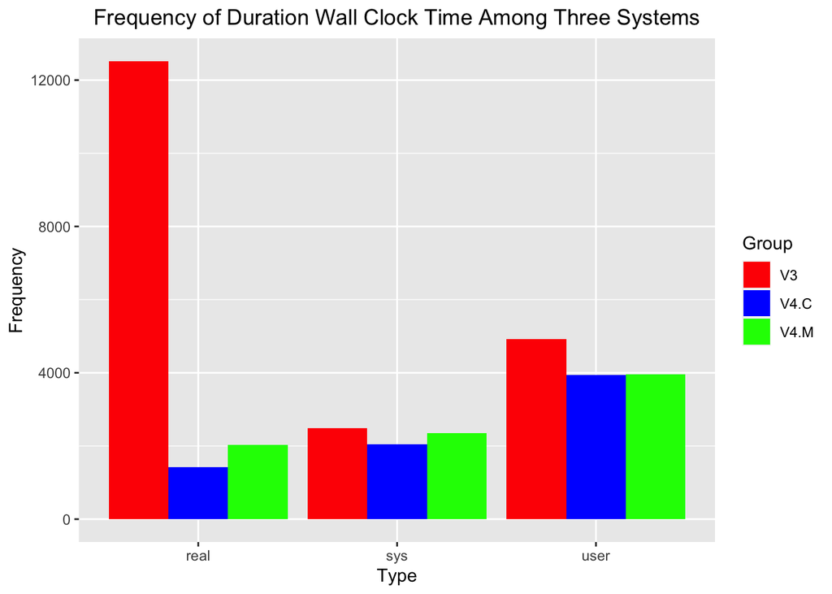

```r
# Create the histogram with three groups
ggplot(data = time, aes(x = time$Type, y = time$Fequency, fill = time$group)) +
  geom_histogram(stat = "identity", position = "dodge") +
  scale_fill_manual(values = c("red", "blue", "green")) +
  labs(x = "Type", y = "Frequency", fill = "Group") +
  ggtitle("Frequency of Duration Wall Clock Time Among Three Systems") +
  theme(plot.title = element_text(hjust = 0.5))
```

We can draw a plot to see it in a more intuitive way that V3 are more efficient.

We can also do the same process for query that returns rows and none. However, due to the limitation of time. I won’t do it here.

# Future Work

In Future Work, we can make use of the query history file. I have a general ideal of how to use it but I don’t have enough time here.

In the data cleanning process, I already clean up the query history file and we can look at the query type by split the spec with “–”. If we combine these system log file with history file, we can combine what type of query usually takes more time (real, user, sys). What type of query is most efficient on which system, or what systems is most efficient for what type of query, etc.

There will be a lot of things we can do by combining the history query file with these three.

There is also some deficiency of my analysis here.

1. I assume there will only be four “__” in the query type, but it is not guranteed. I’m still trying to figure out a way of doing it
2. The EDA I developed doesn’t give a clear results
3. I wrote too much redundant code. What I should do is design function in the beginning and make use of it instead of writing the function everytime
4. Documentation is a bit messy.

In conclusion, From all the EDA and table, V3 seems has the shortest wall- clock time to run the query under any circustances we talked here. For CPU and kernel time, each system has close running time on cpu and kernel, V3 has a little bit of advantes

My assumption is that for V3, the design is good, but for some reason, the no starts reach it limit (There is nearly 2 billion row) due to the deficiency of the database. Then, we need to change it. The V4.C and V4.M looks both fine, for my preference, I probably will go with V4.M since it performes a little bit better than V4.C

I will do a further assumption towawrds V3, V4.C, and V4.M dataset and why we are developing new system.

As I mentioned above, the V3 system could work very well, and treat no as the primary key. However, as the number of the observation increases, the number of primary key starts to reach it limits and it is also very hard to come up with a new primary key. Therefore, developer developed two new system called V4.C and V4.M. My assumeption is that for constraint type of system, it largely reduce the useless and redundant information. The merged based system cuold have multiple databse in different location and it largely extent avilibility of the schema.

By assumption, in this particular dataset, V3 performs well might because of some certain query type dominant. I guess V4.C and V4.M are extremely useful to look for certain types of query since it may only need to scan through 1/n dataset to look for particular rows.

#############################################Query History Analysis##################################################

```r
type1 <- unique(history_sep$type1)
type2 <- unique(history_sep$type2)
type3 <- unique(history_sep$type3)
type4 <- unique(history_sep$type4)
```

```r
type1
```

```
## [1] "asof-0x1"   "geo-0x1"    "geo-0x200"  "geo-0xSTAR"
```

```r
type2
```

```
## [1] "geo-0x1"       "geo-0x2"       "geo-0x5"       "geo-0xSTAR"
## [5] "issue-0x1"     "issue-0xRANGE" "lag-0x1"
```

```r
type3
```

```
## [1] "signal-0x1"
```

Here, since the signal- 0*1, for this particular dataset, the signal identifier pull a number of spefici value.

```r
type4
```

```
##  [1] "time-0x120"   "time-0x1"     "time-0x3"     "time-0x48"    "time-0x54"
##  [6] "time-0x59"    "time-0xRANGE" "time-0x10"    "time-0x112"   "time-0x119"
## [11] "time-0x126"   "time-0x12"    "time-0x13"    "time-0x149"   "time-0x14"
## [16] "time-0x15"    "time-0x16"    "time-0x17"    "time-0x18"    "time-0x19"
## [21] "time-0x20"    "time-0x21"    "time-0x22"    "time-0x23"    "time-0x24"
## [26] "time-0x25"    "time-0x26"    "time-0x27"    "time-0x28"    "time-0x29"
## [31] "time-0x2"     "time-0x30"    "time-0x31"    "time-0x32"    "time-0x33"
## [36] "time-0x34"    "time-0x35"    "time-0x36"    "time-0x37"    "time-0x38"
## [41] "time-0x39"    "time-0x40"    "time-0x41"    "time-0x42"    "time-0x43"
## [46] "time-0x44"    "time-0x45"    "time-0x46"    "time-0x47"    "time-0x49"
## [51] "time-0x4"     "time-0x50"    "time-0x51"    "time-0x52"    "time-0x53"
## [56] "time-0x55"    "time-0x56"    "time-0x57"    "time-0x58"    "time-0x5"
## [61] "time-0x60"    "time-0x61"    "time-0x62"    "time-0x63"    "time-0x64"
## [66] "time-0x65"    "time-0x66"    "time-0x68"    "time-0x6"     "time-0x70"
## [71] "time-0x79"    "time-0x7"     "time-0x84"    "time-0x8"     "time-0x91"
## [76] "time-0x98"    "time-0x9"     "time-0x1953"  "time-0x196"
```

We can combine the history dataset with the system log file

```r
combine <- cbind(history_sep, pairwise)
```

From here, we can use the combine dataset to do all kinds of operation like finding patterns of severl query type, find query taht has largest run time of real, user, and sys and analyze these query.

```r
#Wall-Clock Time
# Find the row index with the max value in real-V3
max_real_V3_idex <- which.max(combine$V3_real)
# Find the row index with the max value in real-V4.C
max_real_V4.C_idex <- which.max(combine$V4.C_real)
# Find the row index with the max value in real-V4.M
max_real_V4.C_idex <- which.max(combine$V4.M_real)

# CPU Run Time
# Find the row index with the max value in real-V3
max_cpu_V3_idex <- which.max(combine$V3_user)
# Find the row index with the max value in real-V4.C
max_cpu_V4.C_idex <- which.max(combine$V4.C_user)
# Find the row index with the max value in real-V4.M
max_cpu_V4.M_idex <- which.max(combine$V4.M_user)


# Kernel Run Time
# Find the row index with the max value in real-V3
max_ker_V3_idex <- which.max(combine$V3_sys)
# Find the row index with the max value in real-V4.C
max_ker_V4.C_idex <- which.max(combine$V4.C_sys)
# Find the row index with the max value in real-V4.M
max_ker_V4.M_idex <- which.max(combine$V4.M_sys)
```

```r
# Subset the data frame to get the row with the max value in V3_real
max_query_V3_real <- combine[max_real_V3_idex, ]
# Subset the data frame to get the row with the max value in V3_real
max_query_V4.C_real <- combine[max_real_V4.C_idex, ]
# Subset the data frame to get the row with the max value in V3_real
max_query_V4.M_real <- combine[max_real_V4.C_idex, ]

# Subset the data frame to get the row with the max value in V3_real
max_query_V3_cpu <- combine[max_cpu_V3_idex, ]
# Subset the data frame to get the row with the max value in V3_real
max_query_V4.C_cpu <- combine[max_cpu_V4.C_idex, ]
# Subset the data frame to get the row with the max value in V3_real
max_query_V4.M_cpu <- combine[max_cpu_V4.M_idex, ]


# Subset the data frame to get the row with the max value in V3_real
max_query_V3_ker <- combine[max_ker_V3_idex, ]
# Subset the data frame to get the row with the max value in V3_real
max_query_V4.C_ker <- combine[max_ker_V4.C_idex, ]
# Subset the data frame to get the row with the max value in V3_real
max_query_V4.M_ker <- combine[max_ker_V4.M_idex, ]


# Building a dataset that contains the ma real, user, and sys run time among three systems
max_query_df <- rbind(max_query_V3_real, max_query_V4.C_real, max_query_V4.M_real,
                      max_query_V3_cpu, max_query_V4.C_cpu, max_query_V4.M_cpu,
                      max_query_V3_ker, max_query_V4.C_ker, max_query_V4.M_ker)
max_query_df
```

|  | type1 | type2 | type3 | type4 | actual | no | V3_real | V3_user | V3_sys | V4.C_real | V4.C_user | V4.C_sys | V4.M_real | V4.M_user | V4.M_sys |
| --- | --- | --- | --- | --- | --- | --- | --- | --- | --- | --- | --- | --- | --- | --- | --- |
| 3987 | asof-0x1 | geo-0x2 | signal-0x1 | time-0xRANGE | SELECT t.geo_value, t.signal, t.time_value, t.issue, t.lag, t.value, t.stderr, t.sample_size, t.geo_type, t.source FROM covidcast t JOIN (SELECT max(issue) max_issue, time_type, time_value, `source`, … | 3987 | 17.121 | 0.024 | 0.009 | 5.505 | 0.025 | 0.008 | 5.049 | 0.026 | 0.006 |
| 4485 | geo-0x200 | lag-0x1 | signal-0x1 | time-0x18 | SELECT t.geo_value, t.signal, t.time_value, t.direction, t.issue, t.lag, t.missing_value, t.missing_stderr, t.missing_sample_size, t.value, t.stderr, t.sample_size FROM covidcast t WHERE ((t.source = … | 4485 | 0.522 | 0.006 | 0.000 | 15.997 | 0.007 | 0.000 | 12.788 | 0.000 | 0.006 |
| 44851 | geo-0x200 | lag-0x1 | signal-0x1 | time-0x18 | SELECT t.geo_value, t.signal, t.time_value, t.direction, t.issue, t.lag, t.missing_value, t.missing_stderr, t.missing_sample_size, t.value, t.stderr, t.sample_size FROM covidcast t WHERE ((t.source = … | 4485 | 0.522 | 0.006 | 0.000 | 15.997 | 0.007 | 0.000 | 12.788 | 0.000 | 0.006 |
| 39871 | asof-0x1 | geo-0x2 | signal-0x1 | time-0xRANGE | SELECT t.geo_value, t.signal, t.time_value, t.issue, t.lag, t.value, t.stderr, t.sample_size, t.geo_type, t.source FROM covidcast t JOIN (SELECT max(issue) max_issue, time_type, time_value, `source`, … | 3987 | 17.121 | 0.024 | 0.009 | 5.505 | 0.025 | 0.008 | 5.049 | 0.026 | 0.006 |
| 39872 | asof-0x1 | geo-0x2 | signal-0x1 | time-0xRANGE | SELECT t.geo_value, t.signal, t.time_value, t.issue, t.lag, t.value, t.stderr, t.sample_size, t.geo_type, t.source FROM covidcast t JOIN (SELECT max(issue) max_issue, time_type, time_value, `source`, … | 3987 | 17.121 | 0.024 | 0.009 | 5.505 | 0.025 | 0.008 | 5.049 | 0.026 | 0.006 |
| 39873 | asof-0x1 | geo-0x2 | signal-0x1 | time-0xRANGE | SELECT t.geo_value, t.signal, t.time_value, t.issue, t.lag, t.value, t.stderr, t.sample_size, t.geo_type, t.source FROM covidcast t JOIN (SELECT max(issue) max_issue, time_type, time_value, `source`, … | 3987 | 17.121 | 0.024 | 0.009 | 5.505 | 0.025 | 0.008 | 5.049 | 0.026 | 0.006 |
| 5241 | geo-0xSTAR | issue-0xRANGE | signal-0x1 | time-0x1 | SELECT t.geo_value, t.signal, t.time_value, t.direction, t.issue, t.lag, t.missing_value, t.missing_stderr, t.missing_sample_size, t.value, t.stderr, t.sample_size FROM covidcast t WHERE ((t.source = … | 5241 | 0.061 | 0.000 | 0.010 | 0.092 | 0.011 | 0.000 | 0.082 | 0.010 | 0.000 |
| 1 | asof-0x1 | geo-0x1 | signal-0x1 | time-0x120 | SELECT t.geo_value, t.signal, t.time_value, t.direction, t.issue, t.lag, t.missing_value, t.missing_stderr, t.missing_sample_size, t.value, t.stderr, t.sample_size FROM covidcast t JOIN (SELECT max(is… | 1 | 0.424 | 0.003 | 0.003 | 1.316 | 0.000 | 0.011 | 1.838 | 0.007 | 0.000 |
| 6071 | geo-0xSTAR | issue-0xRANGE | signal-0x1 | time-0x1 | SELECT t.geo_value, t.signal, t.time_value, t.direction, t.issue, t.lag, t.missing_value, t.missing_stderr, t.missing_sample_size, t.value, t.stderr, t.sample_size FROM covidcast t WHERE ((t.source = … | 6071 | 0.083 | 0.011 | 0.000 | 2.232 | 0.011 | 0.000 | 0.784 | 0.000 | 0.011 |

From the table, one thing we find interesting is that for max cpu run time seems linked quite tightly with time-0xRANGE.

# Select the 5% percent of the shortest real run time

```r
# Get the number of rows in the data frame
n <- nrow(combine)
# Select the smallest 5% of values for column 'value'
# I should be able to write a for loop from 7th colmn to the end

#V3
V3_real_smallest <- combine %>%
  slice_min(V3_real, n = floor(0.05 * n))
V3_real_smallest <- V3_real_smallest[, 1:4]
V3_user_smallest <- combine %>%
  slice_min(V3_user, n = floor(0.05 * n))
V3_user_smallest <- V3_user_smallest[, 1:4]
V3_sys_smallest <- combine %>%
  slice_min(V3_sys, n = floor(0.05 * n))
V3_sys_smallest <- V3_sys_smallest[, 1:4]


#V4.C
V4.C_real_smallest <- combine %>%
  slice_min(V4.C_real, n = floor(0.05 * n))
V4.C_real_smallest <- V4.C_real_smallest[, 1:4]
V4.C_user_smallest <- combine %>%
  slice_min(V4.C_user, n = floor(0.05 * n))
V4.C_user_smallest <- V4.C_user_smallest[, 1:4]
V4.C_sys_smallest <- combine %>%
  slice_min(V4.C_sys, n = floor(0.05 * n))
V4.C_sys_smallest <- V4.C_sys_smallest[, 1:4]



#V4.M
V4.M_real_smallest <- combine %>%
  slice_min(V4.M_real, n = floor(0.05 * n))
V4.M_real_smallest <- V4.M_real_smallest[, 1:4]
V4.M_user_smallest <- combine %>%
  slice_min(V4.M_user, n = floor(0.05 * n))
V4.M_user_smallest <- V4.M_user_smallest[, 1:4]
V4.M_sys_smallest <- combine %>%
  slice_min(V4.M_sys, n = floor(0.05 * n))
V4.M_sys_smallest <- V4.M_sys_smallest[, 1:4]
```

```r
# Define a function called type_freq
# Find the frequency of query type in 5% smallest run time
#input: dataframe
type_freq <- function(df) {
  freq_tables <- list() # initialize an empty list to store frequency tables for each column

  # Loop through each column in the data frame
  for (i in 1:ncol(df)) {

    # Get the column name
    col_name <- colnames(df)[i]

    # Create a frequency table for the column
    freq_table <- table(df[[i]])

    # Assign the frequency table to the list with the column name as the list element name
    freq_tables[[col_name]] <- freq_table

  }

  # Print the frequency tables for each column
  print(freq_tables)
}
```

```r
type_freq(V3_real_smallest)
```

```
## $type1
##
##   asof-0x1    geo-0x1 geo-0xSTAR
##        267         65       3578
##
## $type2
##
##       geo-0x1    geo-0xSTAR issue-0xRANGE
##           261             6          3643
##
## $type3
##
## signal-0x1
##       3910
##
## $type4
##
## time-0x1
##     3910
```

```r
type_freq(V4.C_real_smallest)
```

```
## $type1
##
##   asof-0x1    geo-0x1 geo-0xSTAR
##       1139         33        953
##
## $type2
##
##       geo-0x1    geo-0xSTAR issue-0xRANGE
##          1138             1           986
##
## $type3
##
## signal-0x1
##       2125
##
## $type4
##
##     time-0x1 time-0xRANGE
##         2124            1
```

```r
type_freq(V4.M_real_smallest)
```

```
## $type1
##
##   asof-0x1 geo-0xSTAR
##       1690       1988
##
## $type2
##
##       geo-0x1    geo-0xSTAR     issue-0x1 issue-0xRANGE
##          1641            49             1          1987
##
## $type3
##
## signal-0x1
##       3678
##
## $type4
##
##     time-0x1     time-0x3 time-0xRANGE
##         3676            1            1
```

# I know this is a list, but I can’t subract the value in this list. Therefore, I can’t do visulization to this.

This is meaningful since we choose smallest 5% of data for each system and for each run time. Then, we can find the corresponding query type to see what is unique or what is the most frequent to maybe find something interesting.

#############################################Work Done Here##########################################################

There are certainly a lot of things I can futher analysis. I believe once I have the stucture of the scheme or the return column, I can do more.